# Practical Machine Learning Project 1

Griffin Mathews

December 17, 2020

# Introduction

The goal of this project is to predict the correctness of different types of exercises done while wearing a fitness device. We will begin by loading required libraries for prediction.

```r
library(caret)
library(AppliedPredictiveModeling)
library(rattle)
library(randomForest)
```

```r
library(corrplot)
library(Hmisc)
print("Success")
```

```
## [1] "Success"
```

## Load Data

```r
training <- read.csv(url("https://d396qusza40orc.cloudfront.net/predmachlearn/pml-training.csv"))
testing <- read.csv(url("https://d396qusza40orc.cloudfront.net/predmachlearn/pml-testing.csv"))
#str(training)
```

## Cleaning Data

```r
naColumns <- which(colSums(is.na(training))>0.8)
trainingClean <- training[, -naColumns]
trainingClean <- trainingClean[, -c(1:7)]

testingClean <- testing[, -naColumns]
testingClean <- testingClean[, -c(1:7)]

dim(trainingClean)
```

```
## [1] 19622    86
```

After initial cleaning, only 86 columns remain. Lets remove variables with very little variation, as these add very little to the model.

```r
nearZero <- nearZeroVar(testingClean)
trainingClean <- trainingClean[,-nearZero]
dim(trainingClean)
```

```
## [1] 19622    53
```

```r
corPlot <- cor(trainingClean[,-53])
zdf <- as.data.frame(as.table(corPlot))
highCorr <- subset(zdf, Freq > 0.5)
highCorr
```

```
##                      Var1                 Var2      Freq
## 1               roll_belt            roll_belt 1.0000000
## 3                yaw_belt            roll_belt 0.8152297
## 4        total_accel_belt            roll_belt 0.9809241
## 9            accel_belt_y            roll_belt 0.9248983
## 20            gyros_arm_z            roll_belt 0.5467935
## 54             pitch_belt           pitch_belt 1.0000000
## 81           yaw_dumbbell           pitch_belt 0.6600254
## 88       accel_dumbbell_z           pitch_belt 0.5383407
## 105             roll_belt             yaw_belt 0.8152297
## 107              yaw_belt             yaw_belt 1.0000000
## 108      total_accel_belt             yaw_belt 0.7620963
## 110          gyros_belt_y             yaw_belt 0.5300448
## 112          accel_belt_x             yaw_belt 0.7080277
## 113          accel_belt_y             yaw_belt 0.6005466
```

[output cut: 134 more lines]

Based on this, we will remove: - yaw_belt - total_accel_belt - accel_belt_y

```r
trainingClean <- subset(trainingClean, select=-c(yaw_belt,total_accel_belt, accel_belt_y))
dim(trainingClean)
```

```
## [1] 19622    50
```

The seed is set to allow for reproduceability and then split the data into training and testing sets with a 75/25 split. Cross Validation is used in the creation of the model with 10 folds.

```r
set.seed(456789)
inTrain1 <- createDataPartition(trainingClean$classe, p=0.75, list=FALSE)
Train1 <- trainingClean[inTrain1,]
Test1 <- trainingClean[-inTrain1,]
dim(Train1)
```

```
## [1] 14718    50
```

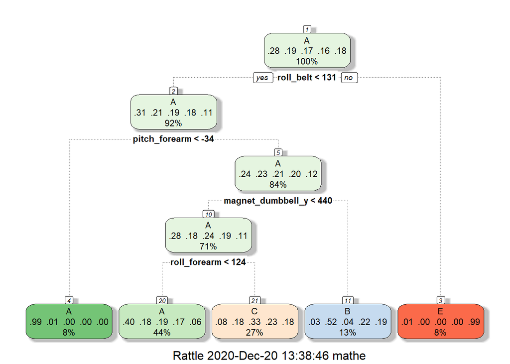

```r
fitControl <- trainControl(method = 'cv', number = 10)
mod_ct <- train(classe ~ .,
                data = Train1,
                method = 'rpart',
                trControl = fitControl)

fancyRpartPlot(mod_ct$finalModel)
```

```r
pred_ct <- predict(mod_ct, Test1)
confusionMatrix(pred_ct, as.factor(Test1$classe))$overall[1]
```

```
##  Accuracy
## 0.4987765
```

Unfortunately, the classification tree model is only accurate ~50% of the time. This next model will use random forest to try and increase the accuracy of the prediction.

```r
set.seed(456789)
inTrain1 <- createDataPartition(trainingClean$classe, p=0.75, list=FALSE)
Train1 <- trainingClean[inTrain1,]
Test1 <- trainingClean[-inTrain1,]
dim(Train1)
```

```
## [1] 14718    50
```

```r
fitControl <- trainControl(method = 'cv', number = 10)
mod_rf <- train(classe ~ .,
                data = Train1,
                method = 'rf',
                trControl = fitControl)

pred_rf <- predict(mod_rf, Test1)
confusionMatrix(pred_rf, as.factor(Test1$classe))$overall[1]
```

```
##  Accuracy
## 0.9930669
```

The random forest model significantly improves the prediction accuracy of the model, with almost 99% accuracy. An accuracy of 99% implies an out of sample error of ~0, but this could be due to overfitting. Lets check the plot the model.

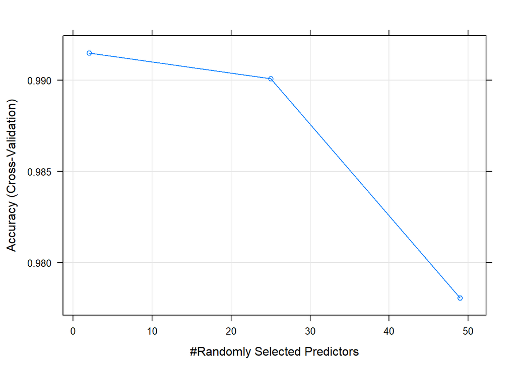

```r
plot(mod_rf)
```

```r
set.seed(456789)
inTrain1 <- createDataPartition(trainingClean$classe, p=0.75, list=FALSE)
Train1 <- trainingClean[inTrain1,]
Test1 <- trainingClean[-inTrain1,]
dim(Train1)
```

```
## [1] 14718    50
```

```r
fitControl <- trainControl(method = 'cv', number = 10)
mod_gbm <- train(classe ~ .,
                data = Train1,
                method = 'gbm',
                trControl = fitControl)
mod_gbm$finalModel
```

```
## A gradient boosted model with multinomial loss function.
## 150 iterations were performed.
## There were 49 predictors of which 49 had non-zero influence.
```

```r
print(mod_gbm)
```

```
## Stochastic Gradient Boosting
##
## 14718 samples
##    49 predictor
##     5 classes: 'A', 'B', 'C', 'D', 'E'
##
## No pre-processing
## Resampling: Cross-Validated (10 fold)
## Summary of sample sizes: 13246, 13247, 13245, 13246, 13247, 13245, ...
## Resampling results across tuning parameters:
##
##   interaction.depth  n.trees  Accuracy   Kappa
##   1                   50      0.7312815  0.6583788
##   1                  100      0.8039807  0.7513253
##   1                  150      0.8414199  0.7989494
##   2                   50      0.8464479  0.8052383
##   2                  100      0.8974075  0.8700887
##   2                  150      0.9224775  0.9018831
##   3                   50      0.8859908  0.8555793
##   3                  100      0.9332124  0.9154825
##   3                  150      0.9548861  0.9429184
##
## Tuning parameter 'shrinkage' was held constant at a value of 0.1
##
## Tuning parameter 'n.minobsinnode' was held constant at a value of 10
## Accuracy was used to select the optimal model using the largest value.
## The final values used for the model were n.trees = 150, interaction.depth =
##  3, shrinkage = 0.1 and n.minobsinnode = 10.
```

```r
predict_gbm <- predict(mod_gbm, newdata=Test1)
cm_gbm <- confusionMatrix(predict_gbm, as.factor(Test1$classe))
cm_gbm
```

```
## Confusion Matrix and Statistics
##
##           Reference
## Prediction    A    B    C    D    E
##          A 1365   37    0    2    1
##          B   15  879   29    4    8
##          C    6   31  810   29    8
##          D    9    2   13  764   17
##          E    0    0    3    5  867
##
## Overall Statistics
##
##                Accuracy : 0.9553
##                  95% CI : (0.9492, 0.961)
##     No Information Rate : 0.2845
##     P-Value [Acc > NIR] : < 2.2e-16
##
##                   Kappa : 0.9435
##
##  Mcnemar's Test P-Value : 2.779e-06
##
## Statistics by Class:
##
##                      Class: A Class: B Class: C Class: D Class: E
## Sensitivity            0.9785   0.9262   0.9474   0.9502   0.9623
## Specificity            0.9886   0.9858   0.9817   0.9900   0.9980
## Pos Pred Value         0.9715   0.9401   0.9163   0.9491   0.9909
## Neg Pred Value         0.9914   0.9824   0.9888   0.9902   0.9916
## Prevalence             0.2845   0.1935   0.1743   0.1639   0.1837
## Detection Rate         0.2783   0.1792   0.1652   0.1558   0.1768
## Detection Prevalence   0.2865   0.1907   0.1803   0.1642   0.1784
## Balanced Accuracy      0.9835   0.9560   0.9645   0.9701   0.9801
```

The gradient boosted model had a prediction accuracy of 95%, slightly less than the 99% accuracy of the random forest model. However, the gradient boosted model ran significantly faster than the random forest model. For this project the speed of model training isn’t nearly as important, so the random forest model will be used for overall validation.

```r
Results <- predict(mod_rf, newdata = testingClean)
Results
```

```
##  [1] B A B A A E D B A A B C B A E E A B B B
## Levels: A B C D E
```